# Lab 2

Author

Kailyn Kragas

### Loading Your Package In

```r
library(tidyverse)
```

# Data Context

The Portal Project is a long-term ecological study being conducted near Portal, AZ. Since 1977, the site has been used to study the interactions among rodents, ants and plants and their respective responses to climate. To study the interactions among organisms, we experimentally manipulate access to 24 study plots. This study has produced over 100 scientific papers and is one of the longest running ecological studies in the U.S.

We will be investigating the animal species diversity and weights found within plots at the Portal study site. The dataset is stored as a comma separated value (CSV) file. Each row holds information for a single animal, and the columns represent:

| Column | Description |
| --- | --- |
| record_id | Unique id for the observation |
| month | month of observation |
| day | day of observation |
| year | year of observation |
| plot_id | ID of a particular plot |
| species_id | 2-letter code |
| sex | sex of animal (“M”, “F”) |
| hindfoot_length | length of the hindfoot in mm |
| weight | weight of the animal in grams |
| genus | genus of animal |
| species | species of animal |
| taxon | e.g. Rodent, Reptile, Bird, Rabbit |
| plot_type | type of plot |

## Reading Data With The Here Package

**Tip**

You do not need to load the here package if you are only using one function once. Instead, use `here::here()`.

```r
# Code for question 1!
surveys <- read_csv(here::here("Lab 2","surveys.csv"))
```

## Inspecting the Data

### **Question 2**

What are the dimensions of these data?  
*Hint: Writing code is Step 1. You also need to connect the output of the code to what it tells you about the dimensions of the data.*

### **Question 3**

What are the data types of the variables in the dataset?  
*Hint: Yes, this question requires code. No, you do not need anything complicated.*

```r
# Code for questions 2 & 3!
dim(surveys)
```

```
[1] 30463    15
```

```r
spec(surveys)
```

[output not shown]

The data frame has 15 columns and 30,463 rows, which means that it has 15 variables and 30,463 observations.

## Plotting with **`ggplot2`**

### **Question 4: Building a Scatterplot**

First, create a scatterplot of the relationship between `weight` (on the x-axis) and `hindfoot_length` (on the y-axis).

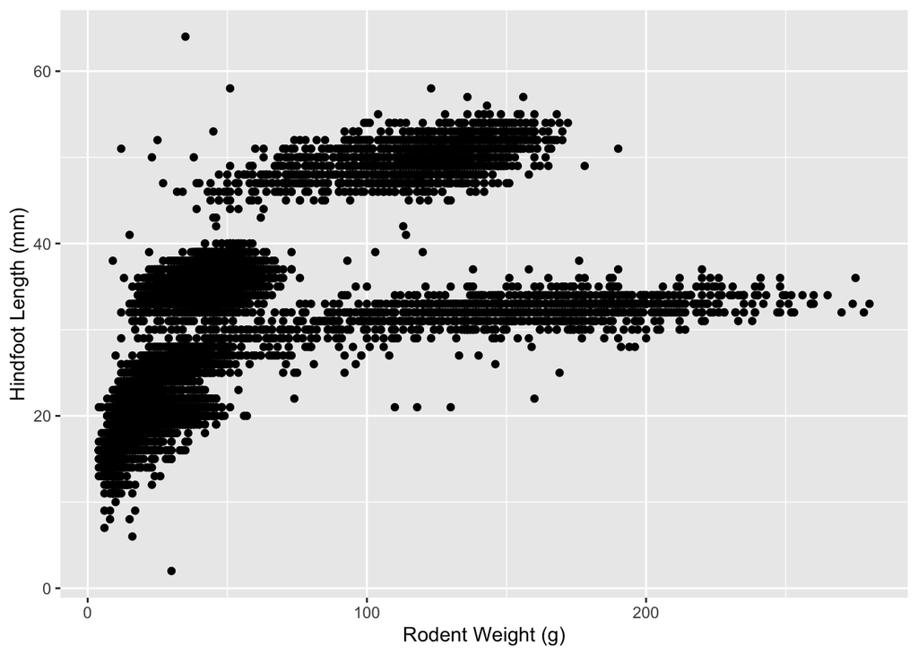

```r
# Code for question 4!
ggplot(data = surveys,
       mapping = aes(x = weight,
                     y = hindfoot_length)) +
  geom_point() +
  labs(x = "Rodent Weight (g)",
       y = "Hindfoot Length (mm)")
```

We can see there are **a lot** of points plotted on top of each other. Let’s try and modify this plot to extract more information from it.

### **Question 5: Using The Alpha Aesthetic**

Add transparency (`alpha`) to the points, to make the points more transparent and (possibly) easier to see.

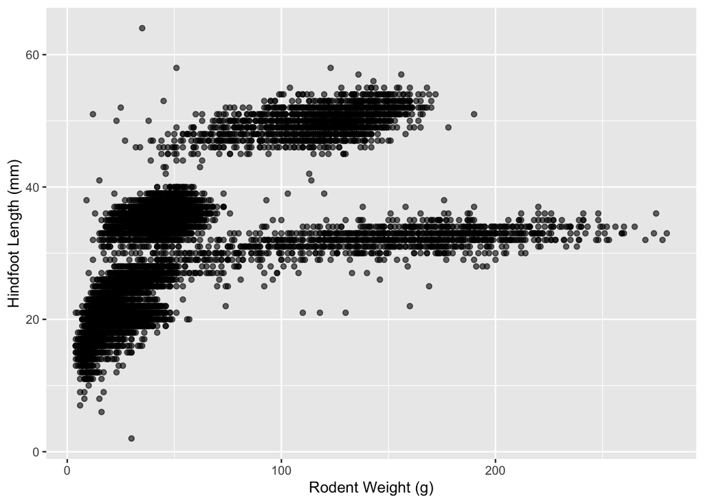

```r
#Code for question 5!
ggplot(data = surveys,
       mapping = aes(x = weight,
                     y = hindfoot_length)) +
  geom_point(alpha = .6) +
  labs(x = "Rodent Weight (g)",
       y = "Hindfoot Length (mm)")
```

Well, that is better, but there are still large clumps of data being plotted on top of each other. Let’s try another tool!

### **Question 6: Adding Jitter to a Scatterplot**

Add some jitter to the points in the scatterplot.  
*Hint: both `geom_point()` and `geom_jitter()` add points to the plot.*

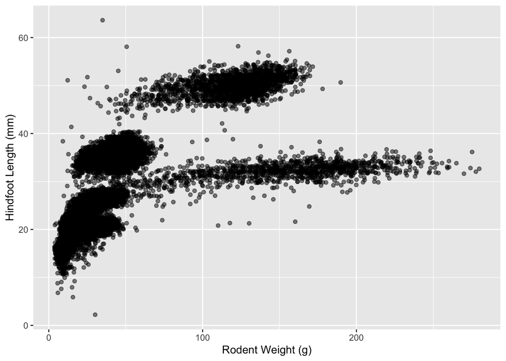

```r
# Code for question 6!
ggplot(data = surveys,
       mapping = aes(x = weight,
                     y = hindfoot_length)) +
   geom_jitter(alpha = 0.5) +
   labs(x = "Rodent Weight (g)",
       y = "Hindfoot Length (mm)")
```

## Faceting

Despite our best efforts there is still a substantial amount of overplotting occurring in our scatterplot. Let’s try splitting the dataset into smaller subsets and see if that allows for us to see the trends a bit better.

### **Question 7:**

Facet your jittered scatterplot by `species`.

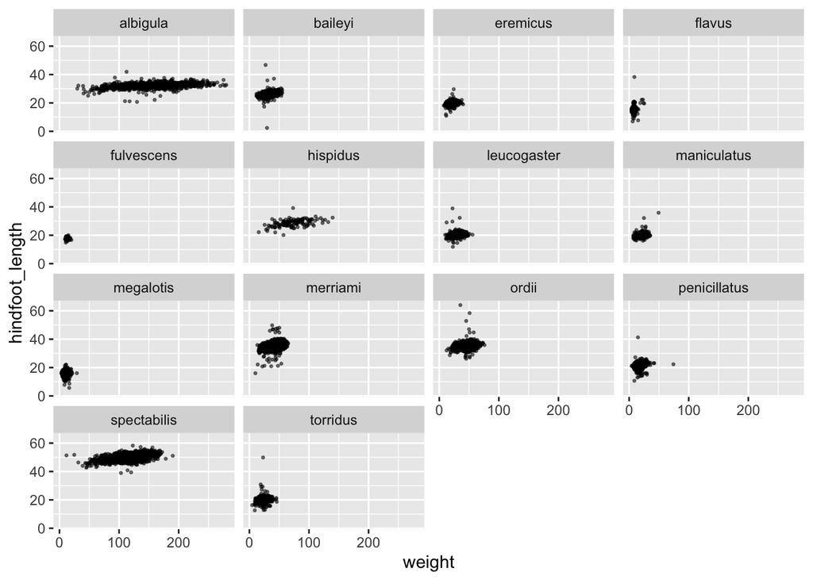

```r
# Code for question 7
ggplot(data = surveys,
       mapping = aes(x = weight,
                     y = hindfoot_length)) +
  geom_jitter(alpha = 0.5,
              size = 0.5) +
  facet_wrap(~ species)
```

# Boxplots & Density Ridges

### **Question 8: Adding Layers to the Boxplot**

Create side-by-side boxplots to visualize the distribution of weight within each species.

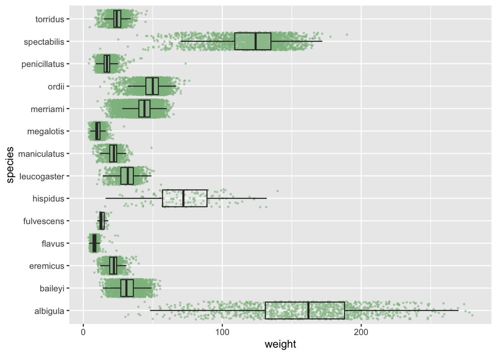

```r
# Code for question 8 (and 9 and 10 and 11 and 12)! :)
ggplot(data = surveys,
  mapping = aes(x = weight,
                y = species)) +
  geom_jitter(color = "darkseagreen",
              size = 0.5,
              alpha = 0.5) +
  geom_boxplot(alpha = 0.1,
               outlier.shape = NA)
```

**Tip**

`outlier.shape = NA` removes the outliers.

A fundamental complaint of boxplots is that they do not plot the raw data. However, with **ggplot** we can add the raw points on top of the boxplots!

### **Question 9**

Add another layer to your previous plot (above) that plots each observation.

Alright, this should look less than optimal. Your points should appear rather stacked on top of each other. To make them less stacked, we need to jitter them a bit, using `geom_jitter()`.

### **Question 10**

Remove the previous layer you had and include a `geom_jitter()` layer.

That should look a bit better! But its really hard to see the points when everything is black.

### **Question 11**

Use the `color` argument in `geom_jitter()` to change the color of the points. You are welcome to use whatever color you wish, some of my favorites are: tomato, cadetblue, and darkseagreen :)

Great! Now that you can see the points, you should notice something odd: there are two colors of points still being plotted. Some of the observations are being plotted twice, once from `geom_boxplot()` as outliers and again from `geom_jitter()`!

### **Question 12**

Inspect the help file for `geom_boxplot()` and see how you can remove the outliers from being plotted by `geom_boxplot()`. Make this change in the code above!

# Customization

Some small changes that make **big** differences to plots. One of these changes are better labels for a plot’s axes and legend.

### **Question 13: Modifying Axis Labels**

Using the code you created in question 12, modify the x-axis and y-axis labels to describe what is being plotted. Be sure to include any necessary units!

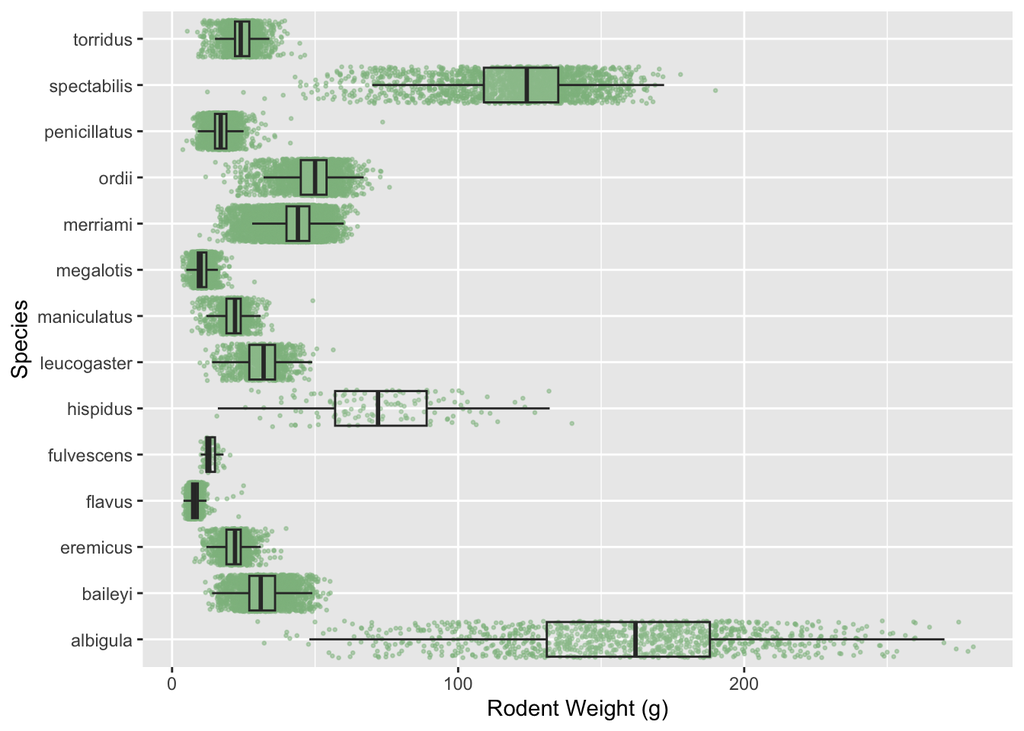

```r
# Code for question 13!
ggplot(data = surveys,
  mapping = aes(x = weight,
                y = species)) +
  geom_jitter(color = "darkseagreen",
              size = 0.5,
              alpha = 0.5) +
  geom_boxplot(alpha = 0.1,
               outlier.shape = NA)  +
  labs(x = "Rodent Weight (g)",
       y = "Species")
```

Some people (and journals) prefer for boxplots to be stacked with a specific orientation! Let’s practice changing the orientation of our boxplots.

### **Question 14: Changing the Orientation**

Flip the orientation of your boxplots from question 10. If you created side-by-side boxplots (stacked horizontally), your boxplots should be stacked vertically. If you had vertically stacked boxplots, you should stack your boxplots horizontally!  
*Hint: You **do not** need to add an additional layer.*

[figure not shown]

```r
# Code for question 14!

ggplot(data = surveys,
  mapping = aes(x = species,
                y = weight)) +
  geom_jitter(color = "darkseagreen",
              size = 0.5,
              alpha = 0.5) +
  geom_boxplot(alpha = 0.1,
               outlier.shape = NA)  +
  labs(x = "Rodent Weight (g)",
       y = "Species",
       title = "The Weight Distribution of Rodents Across Different Species") +
  scale_x_discrete(guide = guide_axis(n.dodge = 2)) +
  theme(plot.title = element_text(face = "bold"),
        axis.title = element_text(size = 10,
                                  face = "bold"),
        axis.text = element_text(size = 6))
```

```r
# added an extra visual layer (scale_x_discrete()) to avoid the stacking of the species labels
# source: https://stackoverflow.com/questions/1330989/rotating-and-spacing-axis-labels-in-ggplot2\
# added an extra visual layer to make the plot title bold

# source: https://www.datanovia.com/en/blog/ggplot-title-subtitle-and-caption/
```

### Reflection:

Attention to detail is a crucial part in doing the labs, and coding in general. Before submitting, make sure everything instructed is complete. To ensure that my peers are able to view the source code, “code-tools: true” needs to be specified in the YAML. This also applies to other YAML options. Another thing to highlight is understanding the data before analyzing it and creating graphs. Labels must be accurate and in tune with the data set. Not knowing your own data makes for an unreliable data scientist.